# Ensemble Technique Project: Travel Package Purchase Prediction

## Problem Statement

### Context

The policymaker of a tourism company named "Visit with us" wants to enable and establish a viable business model to expand the customer base. One of the ways to expand the customer base is to introduce a new offering of packages. Currently, there are 5 types of packages the company is offering - Basic, Standard, Deluxe, Super Deluxe, and King. Looking at the data of the last year, it was observed that 18% of the customers purchased the packages. However, it was difficult to identify the potential customers because customers were contacted at random without looking at the available information.

The company is now planning to launch a new product i.e. Wellness Tourism Package. Wellness Tourism is a package that allows the traveler to maintain, enhance, or kick-start a healthy lifestyle, and support or increase one's sense of well-being. For the launch of the new package, the company wants to harness the available data of existing and potential customers to target the right customers.

### Objective

You as a Data Scientist at "Visit with us" travel company has to analyze the customer data and information to provide recommendations to the policymaker and build a model to predict the chances of a potential customer purchasing the newly introduced travel package before the customer is contacted.

### Data Dictionary

- CustomerID: Unique customer ID
- ProdTaken: Whether the customer has purchased a package or not (0: No, 1: Yes)
- Age: Age of customer
- TypeofContact: How customer was contacted (Company Invited or Self Inquiry)
- CityTier: City tier depends on the development of a city, population, facilities, and living standards. The categories are ordered i.e. Tier 1 > Tier 2 > Tier 3. It's the city the customer lives in.
- DurationOfPitch: Duration of the pitch by a salesperson to the customer
- Occupation: Occupation of customer
- Gender: Gender of customer
- NumberOfPersonVisiting: Total number of persons planning to take the trip with the customer
- NumberOfFollowups: Total number of follow-ups has been done by the salesperson after the sales pitch
- ProductPitched: Product pitched by the salesperson
- PreferredPropertyStar: Preferred hotel property rating by customer
- MaritalStatus: Marital status of customer
- NumberOfTrips: Average number of trips in a year by customer
- Passport: The customer has a passport or not (0: No, 1: Yes)
- PitchSatisfactionScore: Sales pitch satisfaction score
- OwnCar: Whether the customers own a car or not (0: No, 1: Yes)
- NumberOfChildrenVisiting: Total number of children with age less than 5 planning to take the trip with the customer
- Designation: Designation of the customer in the current organization
- MonthlyIncome: Gross monthly income of the customer

## Importing necessary libraries

```python
# Library to suppress warnings or deprecation notes
import warnings
warnings.filterwarnings('ignore')

# Libraries to help with reading and manipulating data
import numpy as np
import pandas as pd

# Libraries to help with data visualization
import matplotlib.pyplot as plt
%matplotlib inline
import seaborn as sns

# Libraries to split data, impute missing values
from sklearn.model_selection import train_test_split
from sklearn.impute import SimpleImputer

# Libraries to import decision tree classifier and different ensemble classifiers
from sklearn.ensemble import BaggingClassifier
from sklearn.ensemble import RandomForestClassifier
from sklearn.ensemble import AdaBoostClassifier, GradientBoostingClassifier
from xgboost import XGBClassifier
from sklearn.ensemble import StackingClassifier
from sklearn.tree import DecisionTreeClassifier

# Libtune to tune model, get different metric scores
from sklearn import metrics
from sklearn.metrics import confusion_matrix, classification_report, accuracy_score, precision_score, recall_score, f1_score, roc_auc_score
from sklearn.model_selection import GridSearchCV
```

```python
from google.colab import drive
drive.mount('/content/drive')
```

## Loading the dataset

```python
tours = pd.read_excel('/content/drive/MyDrive/Python Course/Scikit - Ensemble methods/Tourism.xlsx',sheet_name='Tourism')
```

```python
data = tours.copy()
```

## Data Overview

```python
data.head()
```

|  | CustomerID | ProdTaken | Age | TypeofContact | CityTier | DurationOfPitch | Occupation | Gender | NumberOfPersonVisiting | NumberOfFollowups | ProductPitched | PreferredPropertyStar | MaritalStatus | NumberOfTrips | Passport | PitchSatisfactionScore | OwnCar | NumberOfChildrenVisiting | Designation | MonthlyIncome |
| --- | --- | --- | --- | --- | --- | --- | --- | --- | --- | --- | --- | --- | --- | --- | --- | --- | --- | --- | --- | --- |
| 0 | 200000 | 1 | 41.0 | Self Enquiry | 3 | 6.0 | Salaried | Female | 3 | 3.0 | Deluxe | 3.0 | Single | 1.0 | 1 | 2 | 1 | 0.0 | Manager | 20993.0 |
| 1 | 200001 | 0 | 49.0 | Company Invited | 1 | 14.0 | Salaried | Male | 3 | 4.0 | Deluxe | 4.0 | Divorced | 2.0 | 0 | 3 | 1 | 2.0 | Manager | 20130.0 |
| 2 | 200002 | 1 | 37.0 | Self Enquiry | 1 | 8.0 | Free Lancer | Male | 3 | 4.0 | Basic | 3.0 | Single | 7.0 | 1 | 3 | 0 | 0.0 | Executive | 17090.0 |
| 3 | 200003 | 0 | 33.0 | Company Invited | 1 | 9.0 | Salaried | Female | 2 | 3.0 | Basic | 3.0 | Divorced | 2.0 | 1 | 5 | 1 | 1.0 | Executive | 17909.0 |
| 4 | 200004 | 0 | NaN | Self Enquiry | 1 | 8.0 | Small Business | Male | 2 | 3.0 | Basic | 4.0 | Divorced | 1.0 | 0 | 5 | 1 | 0.0 | Executive | 18468.0 |

```python
data.tail()
```

|  | CustomerID | ProdTaken | Age | TypeofContact | CityTier | DurationOfPitch | Occupation | Gender | NumberOfPersonVisiting | NumberOfFollowups | ProductPitched | PreferredPropertyStar | MaritalStatus | NumberOfTrips | Passport | PitchSatisfactionScore | OwnCar | NumberOfChildrenVisiting | Designation | MonthlyIncome |
| --- | --- | --- | --- | --- | --- | --- | --- | --- | --- | --- | --- | --- | --- | --- | --- | --- | --- | --- | --- | --- |
| 4883 | 204883 | 1 | 49.0 | Self Enquiry | 3 | 9.0 | Small Business | Male | 3 | 5.0 | Deluxe | 4.0 | Unmarried | 2.0 | 1 | 1 | 1 | 1.0 | Manager | 26576.0 |
| 4884 | 204884 | 1 | 28.0 | Company Invited | 1 | 31.0 | Salaried | Male | 4 | 5.0 | Basic | 3.0 | Single | 3.0 | 1 | 3 | 1 | 2.0 | Executive | 21212.0 |
| 4885 | 204885 | 1 | 52.0 | Self Enquiry | 3 | 17.0 | Salaried | Female | 4 | 4.0 | Standard | 4.0 | Married | 7.0 | 0 | 1 | 1 | 3.0 | Senior Manager | 31820.0 |
| 4886 | 204886 | 1 | 19.0 | Self Enquiry | 3 | 16.0 | Small Business | Male | 3 | 4.0 | Basic | 3.0 | Single | 3.0 | 0 | 5 | 0 | 2.0 | Executive | 20289.0 |
| 4887 | 204887 | 1 | 36.0 | Self Enquiry | 1 | 14.0 | Salaried | Male | 4 | 4.0 | Basic | 4.0 | Unmarried | 3.0 | 1 | 3 | 1 | 2.0 | Executive | 24041.0 |

```python
data.shape
```

```
(4888, 20)
```

There are almost 5000 records with 20 columns.

```python
data.info()
```

```
<class 'pandas.core.frame.DataFrame'>
RangeIndex: 4888 entries, 0 to 4887
Data columns (total 20 columns):
 #   Column                    Non-Null Count  Dtype
---  ------                    --------------  -----
 0   CustomerID                4888 non-null   int64
 1   ProdTaken                 4888 non-null   int64
 2   Age                       4662 non-null   float64
 3   TypeofContact             4863 non-null   object
 4   CityTier                  4888 non-null   int64
 5   DurationOfPitch           4637 non-null   float64
 6   Occupation                4888 non-null   object
 7   Gender                    4888 non-null   object
 8   NumberOfPersonVisiting    4888 non-null   int64
 9   NumberOfFollowups         4843 non-null   float64
 10  ProductPitched            4888 non-null   object
 11  PreferredPropertyStar     4862 non-null   float64
 12  MaritalStatus             4888 non-null   object
 13  NumberOfTrips             4748 non-null   float64
 14  Passport                  4888 non-null   int64
 15  PitchSatisfactionScore    4888 non-null   int64
 16  OwnCar                    4888 non-null   int64
 17  NumberOfChildrenVisiting  4822 non-null   float64
 18  Designation               4888 non-null   object
 19  MonthlyIncome             4655 non-null   float64
dtypes: float64(7), int64(7), object(6)
memory usage: 763.9+ KB
```

```python
data.isnull().sum()
```

```
CustomerID                    0
ProdTaken                     0
Age                         226
TypeofContact                25
CityTier                      0
DurationOfPitch             251
Occupation                    0
Gender                        0
NumberOfPersonVisiting        0
NumberOfFollowups            45
ProductPitched                0
PreferredPropertyStar        26
MaritalStatus                 0
NumberOfTrips               140
Passport                      0
PitchSatisfactionScore        0
OwnCar                        0
NumberOfChildrenVisiting     66
Designation                   0
MonthlyIncome               233
dtype: int64
```

1. There are 20 columns
2. 6 non numeric columns
3. 8 columns with null values in them.

```python
data.describe().T
```

|  | count | mean | std | min | 25% | 50% | 75% | max |
| --- | --- | --- | --- | --- | --- | --- | --- | --- |
| CustomerID | 4888.0 | 202443.500000 | 1411.188388 | 200000.0 | 201221.75 | 202443.5 | 203665.25 | 204887.0 |
| ProdTaken | 4888.0 | 0.188216 | 0.390925 | 0.0 | 0.00 | 0.0 | 0.00 | 1.0 |
| Age | 4662.0 | 37.622265 | 9.316387 | 18.0 | 31.00 | 36.0 | 44.00 | 61.0 |
| CityTier | 4888.0 | 1.654255 | 0.916583 | 1.0 | 1.00 | 1.0 | 3.00 | 3.0 |
| DurationOfPitch | 4637.0 | 15.490835 | 8.519643 | 5.0 | 9.00 | 13.0 | 20.00 | 127.0 |
| NumberOfPersonVisiting | 4888.0 | 2.905074 | 0.724891 | 1.0 | 2.00 | 3.0 | 3.00 | 5.0 |
| NumberOfFollowups | 4843.0 | 3.708445 | 1.002509 | 1.0 | 3.00 | 4.0 | 4.00 | 6.0 |
| PreferredPropertyStar | 4862.0 | 3.581037 | 0.798009 | 3.0 | 3.00 | 3.0 | 4.00 | 5.0 |
| NumberOfTrips | 4748.0 | 3.236521 | 1.849019 | 1.0 | 2.00 | 3.0 | 4.00 | 22.0 |
| Passport | 4888.0 | 0.290917 | 0.454232 | 0.0 | 0.00 | 0.0 | 1.00 | 1.0 |
| PitchSatisfactionScore | 4888.0 | 3.078151 | 1.365792 | 1.0 | 2.00 | 3.0 | 4.00 | 5.0 |
| OwnCar | 4888.0 | 0.620295 | 0.485363 | 0.0 | 0.00 | 1.0 | 1.00 | 1.0 |
| NumberOfChildrenVisiting | 4822.0 | 1.187267 | 0.857861 | 0.0 | 1.00 | 1.0 | 2.00 | 3.0 |
| MonthlyIncome | 4655.0 | 23619.853491 | 5380.698361 | 1000.0 | 20346.00 | 22347.0 | 25571.00 | 98678.0 |

```python
data.duplicated().sum()
```

```
0
```

There are no duplicated records.

## Exploratory Data Analysis.

```python
# function to plot a boxplot and a histogram along the same scale.


def histogram_boxplot(data, feature, figsize=(12, 7), kde=False, bins=None):
    """
    Boxplot and histogram combined

    data: dataframe
    feature: dataframe column
    figsize: size of figure (default (12,7))
    kde: whether to show the density curve (default False)
    bins: number of bins for histogram (default None)
    """
    f2, (ax_box2, ax_hist2) = plt.subplots(
        nrows=2,  # Number of rows of the subplot grid= 2
        sharex=True,  # x-axis will be shared among all subplots
        gridspec_kw={"height_ratios": (0.25, 0.75)},
        figsize=figsize,
    )  # creating the 2 subplots
    sns.boxplot(
        data=data, x=feature, ax=ax_box2, showmeans=True, color="violet"
    )  # boxplot will be created and a triangle will indicate the mean value of the column
    sns.histplot(
        data=data, x=feature, kde=kde, ax=ax_hist2, bins=bins
    ) if bins else sns.histplot(
        data=data, x=feature, kde=kde, ax=ax_hist2
    )  # For histogram
    ax_hist2.axvline(
        data[feature].mean(), color="green", linestyle="--"
    )  # Add mean to the histogram
    ax_hist2.axvline(
        data[feature].median(), color="black", linestyle="-"
    )  # Add median to the histogram
```

```python
# function to create labeled barplots


def labeled_barplot(data, feature, perc=False, n=None):
    """
    Barplot with percentage at the top

    data: dataframe
    feature: dataframe column
    perc: whether to display percentages instead of count (default is False)
    n: displays the top n category levels (default is None, i.e., display all levels)
    """

    total = len(data[feature])  # length of the column
    count = data[feature].nunique()
    if n is None:
        plt.figure(figsize=(count + 1, 5))
    else:
        plt.figure(figsize=(n + 1, 5))

    plt.xticks(rotation=90, fontsize=15)
    ax = sns.countplot(
        data=data,
        x=feature,
        palette="Paired",
        order=data[feature].value_counts().index[:n],
    )

    for p in ax.patches:
        if perc == True:
            label = "{:.1f}%".format(
                100 * p.get_height() / total
            )  # percentage of each class of the category
        else:
            label = p.get_height()  # count of each level of the category

        x = p.get_x() + p.get_width() / 2  # width of the plot
        y = p.get_height()  # height of the plot

        ax.annotate(
            label,
            (x, y),
            ha="center",
            va="center",
            size=12,
            xytext=(0, 5),
            textcoords="offset points",
        )  # annotate the percentage

    plt.show()  # show the plot
```

- EDA is an important part of any project involving data.
- It is important to investigate and understand the data better before building a model with it.
- A few questions have been mentioned below which will help you approach the analysis in the right manner and generate insights from the data.
- A thorough analysis of the data, in addition to the questions mentioned below, should be done.

*Univariate Analysis*

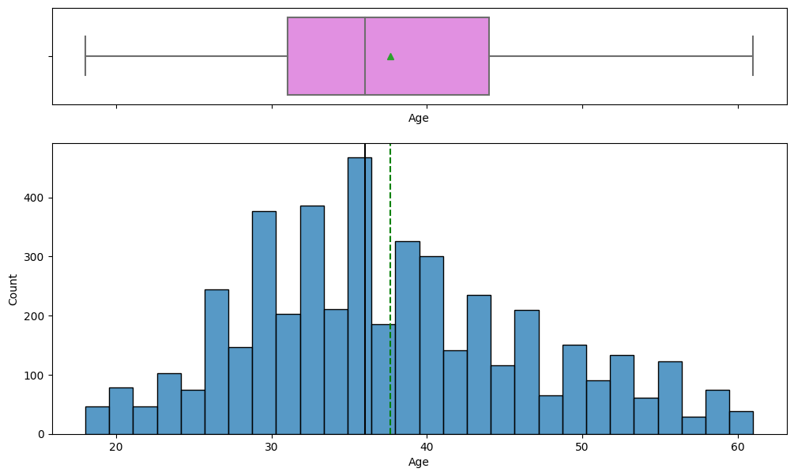

```python
histogram_boxplot(data,'Age')
```

```python
histogram_boxplot(data,'Age')
```

[output not shown]

Age is distributed normally. Median of the age is around 35.

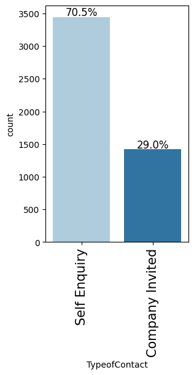

```python
labeled_barplot(data,"TypeofContact",perc=True)
```

Self inquiry has led to more leads that company invited. Company will have to work on a wider outreach program to reach to a wider customer base.

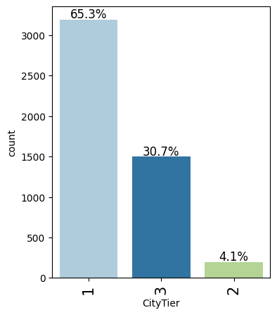

```python
labeled_barplot(data,"CityTier",perc=True)
```

Tier 1 cities produces more customers and Tier 3 customers come second. Tier 2 has the least amout of customers. More focus should be placed in marketting the products in Tier 1 and Tier 3.

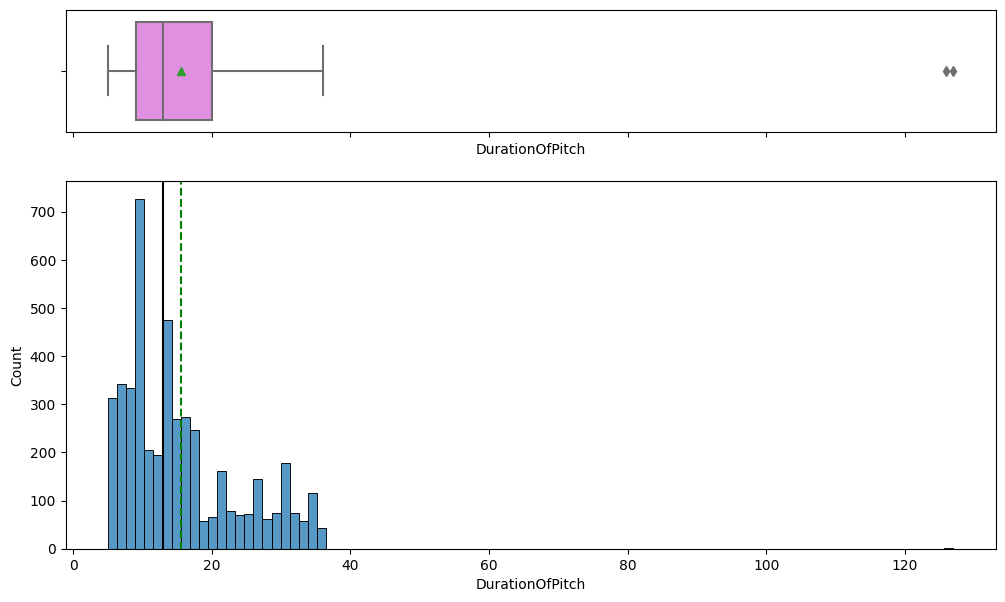

```python
histogram_boxplot(data,'DurationOfPitch')
```

Data for Duration of Pitch is skewed right. There are couple of ouliers. They generally last between 5 t0 36 mins.

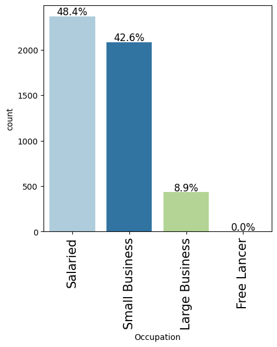

```python
labeled_barplot(data,"Occupation",perc=True)
```

Salaried customers and customers with samll business form the major groups of cutomers.

```python
replaceStruct = {
    "Gender": {"Fe Male": "Female"}
}
```

```python
data = data.replace(replaceStruct)
```

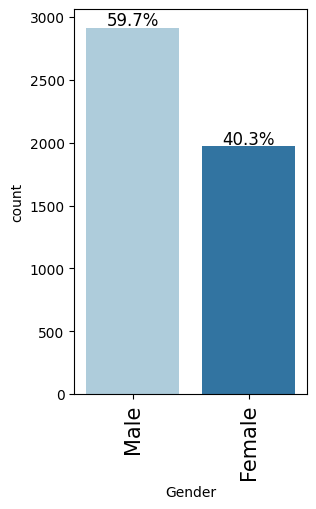

```python
labeled_barplot(data,"Gender",perc=True)
```

60% of the customers are Male and the rest are Female.

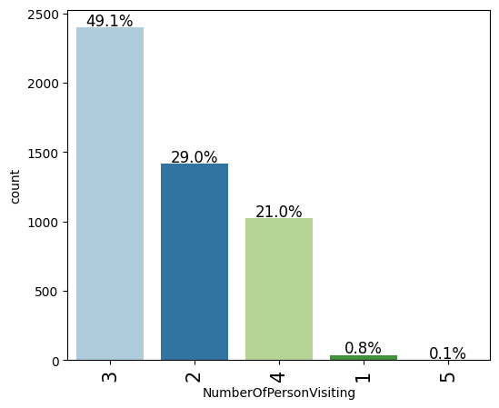

```python
labeled_barplot(data,"NumberOfPersonVisiting",perc=True)
```

50% of the customers visit as a party of 3. 30% as a party of 2 and 20% as a party of 4. customers who are single and bigger parties do not seem to be as interested.

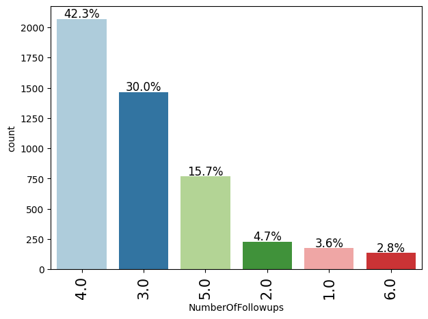

```python
labeled_barplot(data,"NumberOfFollowups",perc=True)
```

Most customers (40%) need 4 follow ups before they come to fruition .

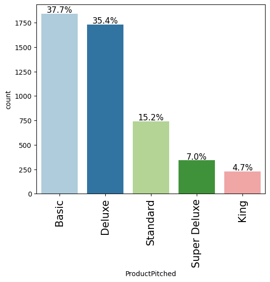

```python
labeled_barplot(data,"ProductPitched",perc=True)
```

Basic and Delux products are pitched the most.

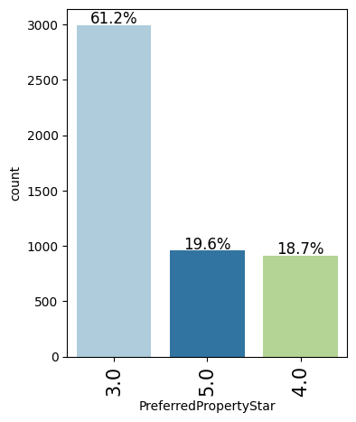

```python
labeled_barplot(data,"PreferredPropertyStar",perc=True)
```

60% of the customers prefer 3 star facillities.

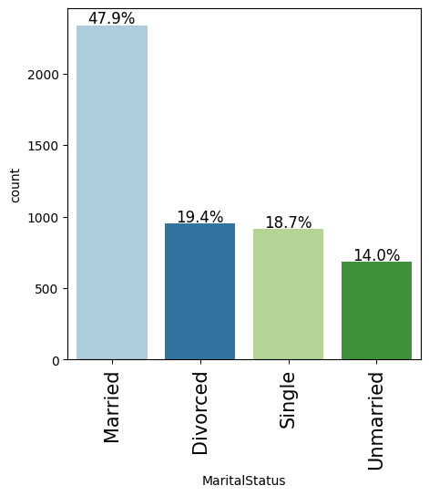

```python
labeled_barplot(data,"MaritalStatus",perc=True)
```

Married cutomers travel the most, this is inline with what we saw earlier with the age. Young families travel the most

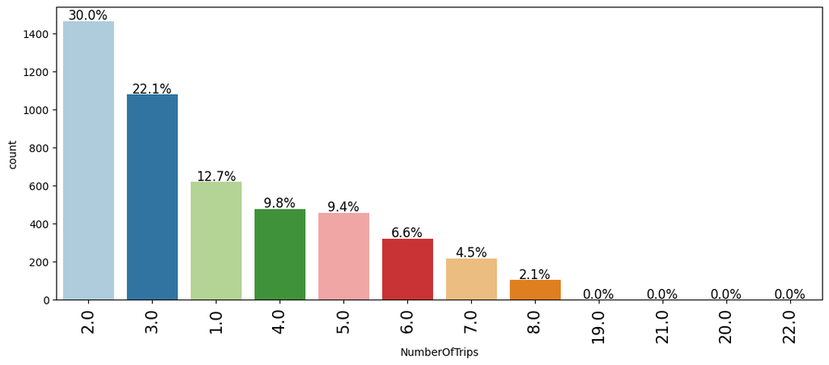

```python
labeled_barplot(data,"NumberOfTrips",perc=True)
```

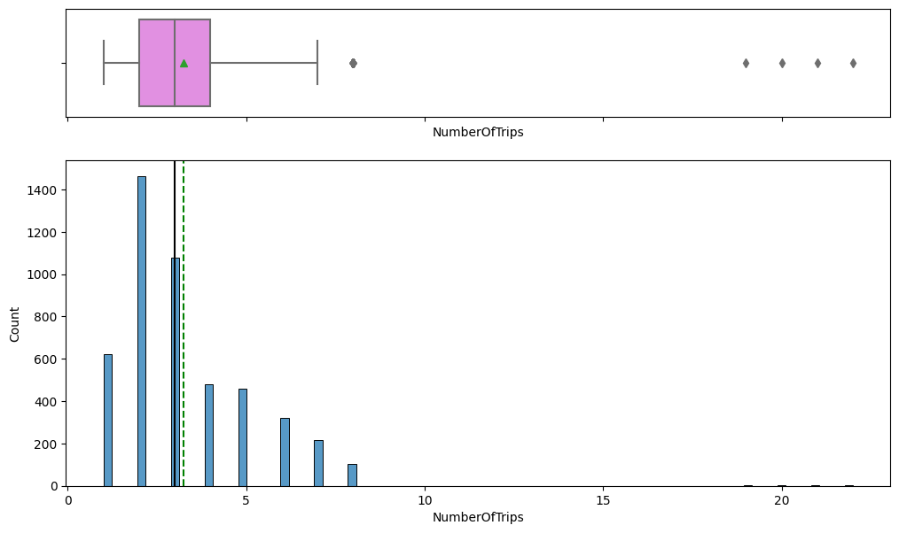

```python
histogram_boxplot(data,'NumberOfTrips')
```

Most customers take 2-3 trips. There are outliers who have taken more than 15 trips

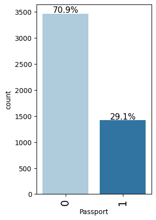

```python
labeled_barplot(data,"Passport",perc=True)
```

70% of customers do not have passports which indicates that they travel within the country

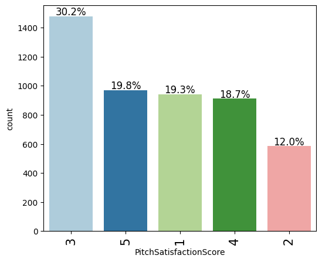

```python
labeled_barplot(data,"PitchSatisfactionScore",perc=True)
```

30% of customers have given middling reviews while 20% are fully satisfied. There is 32% of customers who were not happy with the package.

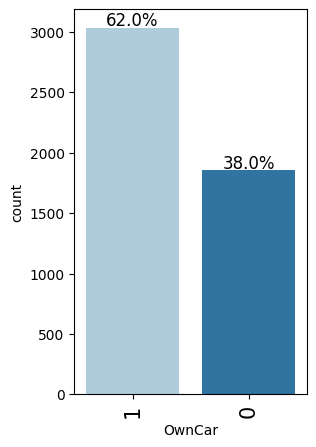

```python
labeled_barplot(data,"OwnCar",perc=True)
```

62% of customers own a car.

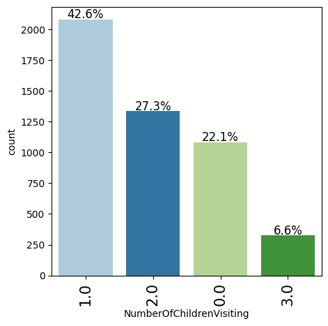

```python
labeled_barplot(data,"NumberOfChildrenVisiting",perc=True)
```

families with more than 3 kids do not seem to travel. Families with 1 or two kids travel the most ( 70%)

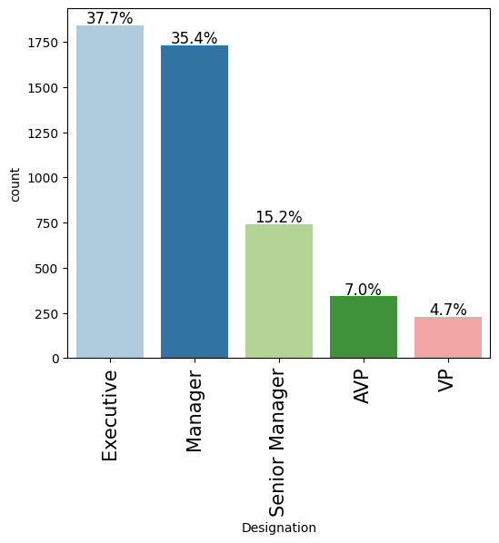

```python
labeled_barplot(data,"Designation",perc=True)
```

Executives and managers travel the most (70%)

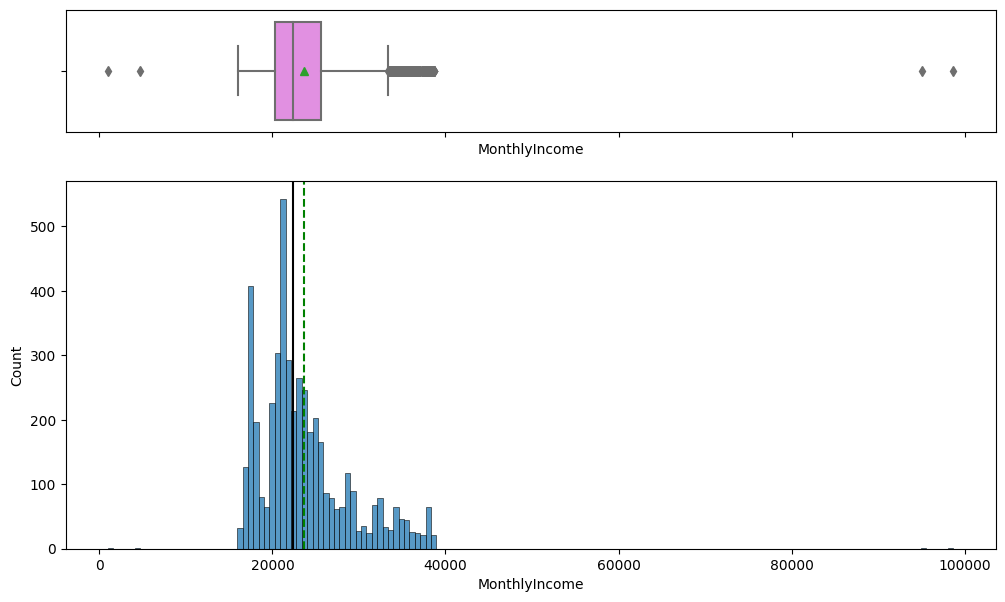

```python
histogram_boxplot(data,'MonthlyIncome')
```

A large section of the customer base is earning between 18k to 40k per month.

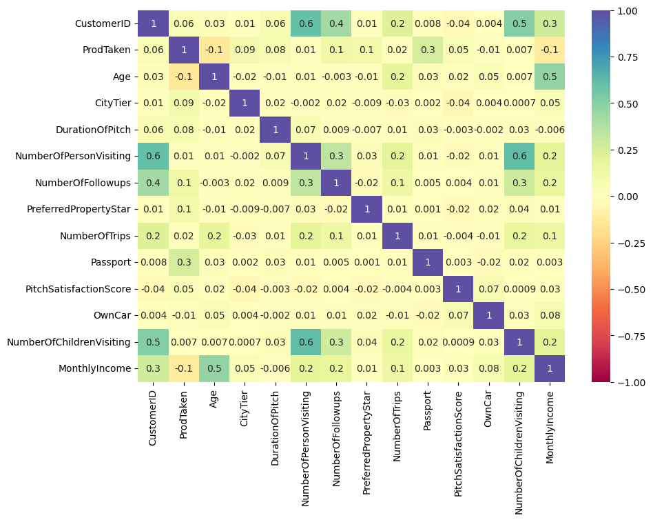

```python
plt.figure(figsize=(10,7))
sns.heatmap(data.corr(),annot=True,vmin=-1,vmax=1,fmt='.1g',cmap="Spectral")
plt.show()
```

Prod taken has negative corellation with monthly Income and age.  
It has stronger corellation with passport  
Number of follow ups and preerred property star have the same level of correlation with Prod taken

```python
def stacked_barplot(data, predictor, target):
    """
    Print the category counts and plot a stacked bar chart

    data: dataframe
    predictor: independent variable
    target: target variable
    """
    count = data[predictor].nunique()
    sorter = data[target].value_counts().index[-1]
    tab1 = pd.crosstab(data[predictor], data[target], margins=True).sort_values(
        by=sorter, ascending=False)
    tab1['PercentageOfPackageTaken'] = tab1[1].div(tab1['All'], axis=0) * 100
    print(tab1)
    print("-" * 120)
    tab = pd.crosstab(data[predictor], data[target]).sort_values(
        by=sorter, ascending=False
    )
    tab.plot(kind="bar", stacked=True, figsize=(count + 5, 5))
    plt.legend(
        loc="lower left",
        frameon=False,
    )
    plt.legend(loc="upper left", bbox_to_anchor=(1, 1))
    plt.show()
```

```python
### function to plot distributions wrt target


def distribution_plot_wrt_target(data, predictor, target):

    fig, axs = plt.subplots(2, 2, figsize=(12, 10))

    target_uniq = data[target].unique()

    axs[0, 0].set_title("Distribution of target for target=" + str(target_uniq[0]))
    sns.histplot(
        data=data[data[target] == target_uniq[0]],
        x=predictor,
        kde=True,
        ax=axs[0, 0],
        color="teal",
        stat="density",
    )

    axs[0, 1].set_title("Distribution of target for target=" + str(target_uniq[1]))
    sns.histplot(
        data=data[data[target] == target_uniq[1]],
        x=predictor,
        kde=True,
        ax=axs[0, 1],
        color="orange",
        stat="density",
    )

    axs[1, 0].set_title("Boxplot w.r.t target")
    sns.boxplot(data=data, x=target, y=predictor, ax=axs[1, 0], palette="gist_rainbow")

    axs[1, 1].set_title("Boxplot (without outliers) w.r.t target")
    sns.boxplot(
        data=data,
        x=target,
        y=predictor,
        ax=axs[1, 1],
        showfliers=False,
        palette="gist_rainbow",
    )

    plt.tight_layout()
    plt.show()
```

```
ProdTaken           0    1   All  PercentageOfPackageTaken
TypeofContact
All              3946  917  4863                 18.856673
Self Enquiry     2837  607  3444                 17.624855
Company Invited  1109  310  1419                 21.846371
------------------------------------------------------------------------------------------------------------------------
```

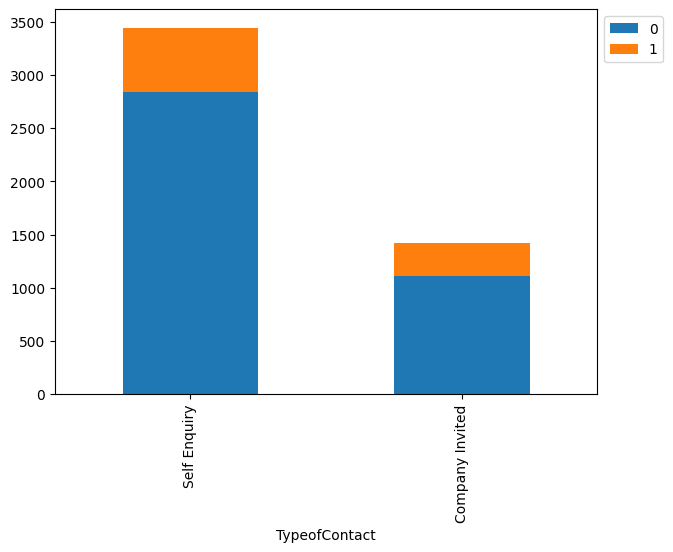

```python
stacked_barplot(data, "TypeofContact", "ProdTaken");
```

Company invited users have a slightly more customers who has taken the package than customers who have enquired by themselves

```
ProdTaken     0    1   All  PercentageOfPackageTaken
CityTier
All        3968  920  4888                 18.821604
1          2670  520  3190                 16.300940
3          1146  354  1500                 23.600000
2           152   46   198                 23.232323
------------------------------------------------------------------------------------------------------------------------
```

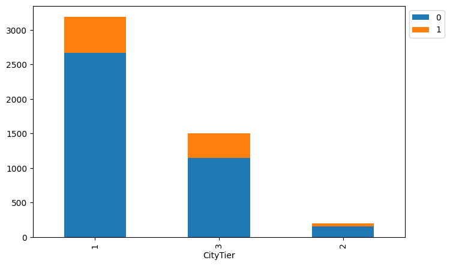

```python
stacked_barplot(data, "CityTier", "ProdTaken");
```

Customers from tier 3 and 2 cities have opted for the package marginally better ratio of customers who took the package to customers who didnt. Tier1 has the most customers though.

```
ProdTaken          0    1   All  PercentageOfPackageTaken
Occupation
All             3968  920  4888                 18.821604
Salaried        1954  414  2368                 17.483108
Small Business  1700  384  2084                 18.426104
Large Business   314  120   434                 27.649770
Free Lancer        0    2     2                100.000000
------------------------------------------------------------------------------------------------------------------------
```

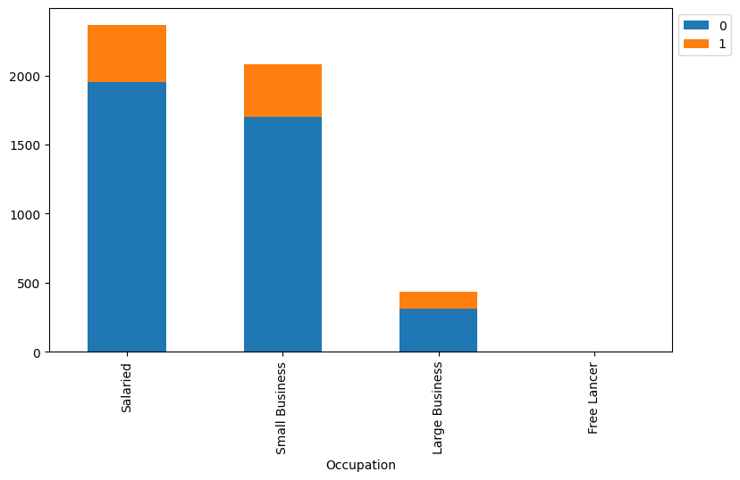

```python
stacked_barplot(data, "Occupation", "ProdTaken");
```

```
ProdTaken     0    1   All  PercentageOfPackageTaken
Gender
All        3968  920  4888                 18.821604
Male       2338  578  2916                 19.821674
Female     1630  342  1972                 17.342799
------------------------------------------------------------------------------------------------------------------------
```

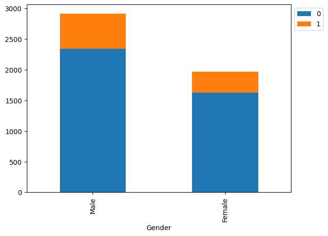

```python
stacked_barplot(data, "Gender", "ProdTaken");
```

More male clients have taken the package that female clients

```
ProdTaken                  0    1   All  PercentageOfPackageTaken
NumberOfPersonVisiting
All                     3968  920  4888                 18.821604
3                       1942  460  2402                 19.150708
2                       1151  267  1418                 18.829337
4                        833  193  1026                 18.810916
1                         39    0    39                  0.000000
5                          3    0     3                  0.000000
------------------------------------------------------------------------------------------------------------------------
```

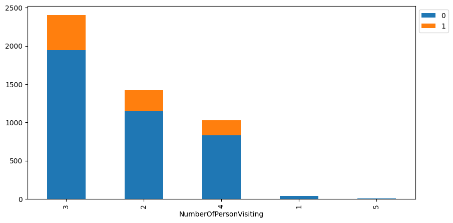

```python
stacked_barplot(data, "NumberOfPersonVisiting", "ProdTaken");
```

People who are by themselves and large families do not opt in for the package. Parties of 3 travel the most.

```
ProdTaken             0    1   All  PercentageOfPackageTaken
NumberOfFollowups
All                3931  912  4843                 18.831303
4.0                1689  379  2068                 18.326886
3.0                1222  244  1466                 16.643929
5.0                 577  191   768                 24.869792
6.0                  82   54   136                 39.705882
2.0                 205   24   229                 10.480349
1.0                 156   20   176                 11.363636
------------------------------------------------------------------------------------------------------------------------
```

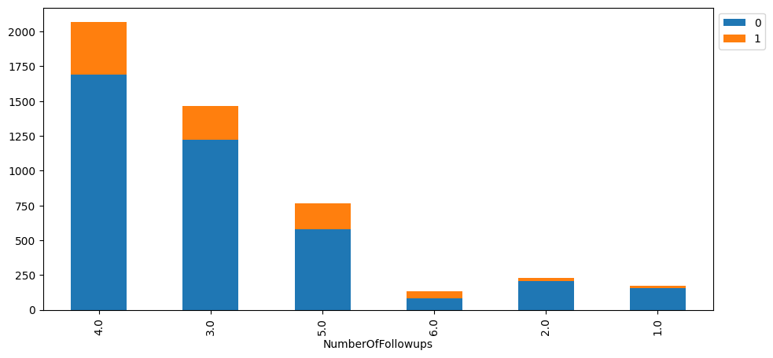

```python
stacked_barplot(data, "NumberOfFollowups", "ProdTaken");
```

Customers who have had more than 3 follow ups tend to opt to take the package.

```
ProdTaken          0    1   All  PercentageOfPackageTaken
ProductPitched
All             3968  920  4888                 18.821604
Basic           1290  552  1842                 29.967427
Deluxe          1528  204  1732                 11.778291
Standard         618  124   742                 16.711590
King             210   20   230                  8.695652
Super Deluxe     322   20   342                  5.847953
------------------------------------------------------------------------------------------------------------------------
```

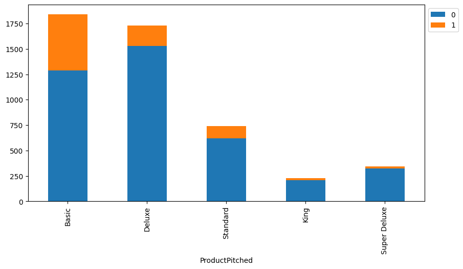

```python
stacked_barplot(data, "ProductPitched", "ProdTaken");
```

Basic, Delux are the top packages. 30 % of customers who were pitched basic package have opeted to take the package.

```
ProdTaken                 0    1   All  PercentageOfPackageTaken
PreferredPropertyStar
All                    3948  914  4862                 18.798848
3.0                    2511  482  2993                 16.104243
5.0                     706  250   956                 26.150628
4.0                     731  182   913                 19.934283
------------------------------------------------------------------------------------------------------------------------
```

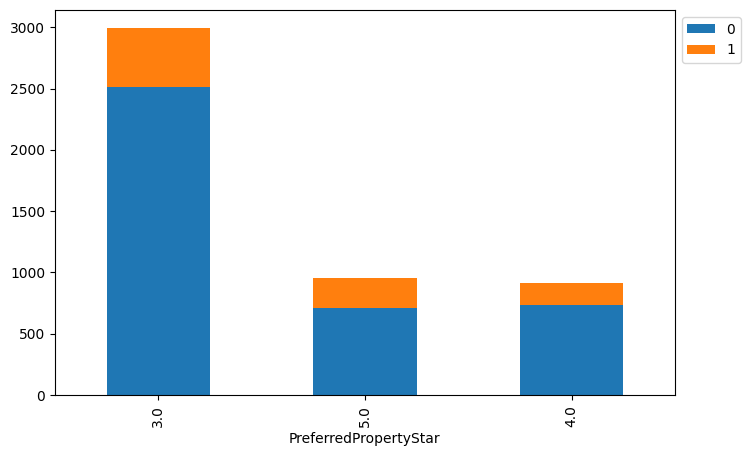

```python
stacked_barplot(data, "PreferredPropertyStar", "ProdTaken");
```

Customers in this dataset mostly prefer the 3 star facillities. 5 star comes second.

```
ProdTaken         0    1   All  PercentageOfPackageTaken
MaritalStatus
All            3968  920  4888                 18.821604
Married        2014  326  2340                 13.931624
Single          612  304   916                 33.187773
Unmarried       516  166   682                 24.340176
Divorced        826  124   950                 13.052632
------------------------------------------------------------------------------------------------------------------------
```

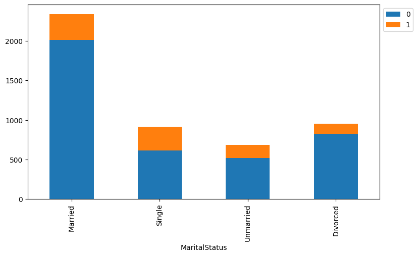

```python
stacked_barplot(data, "MaritalStatus", "ProdTaken");
```

"Visit with us" has a better success rate with single clients as opposed to married and divorced clients. They also have about 25 % of success rate with unmaried clients as well.